# Group Project: Housing Data

Group hisa’R’üstü

## Data Preprocess

After the 92nd row, rows gives information about the numerical . Therefore, numerical data was separated from these information rows and put into another data set.

```r
convertName<-function(x,y){
  x <- gsub(".*- (.+) -.*", "\\1", x)
  x <- gsub("\u008d", "i", x)
  x <- gsub("€", "C", x)
  x <- gsub("ž", "S", x)
  x <- gsub("Ÿ", "s", x)
  x <- gsub("\u0081", "u", x)
  x <- gsub("˜", "I", x)
  x <- gsub("§", "g", x)
  x <- gsub("”", "o", x)
  x <- paste(y, x, sep="_")
  return(x)
}
datainfo = evds[c(92:1080),]
cityNames<-evds[c(95:258),2]
firstHandCityNames<-cityNames[c(1:82)]
secondHandCityNames<-cityNames[c(83:164)]
evds = evds[c(1:91),]
firstHandCityNames<-convertName(firstHandCityNames,"F")
secondHandCityNames<-convertName(secondHandCityNames,"S")
allNames= c("Tarih",firstHandCityNames,secondHandCityNames)
names(evds)<-allNames
```

The home sales data included data with zeros after the comma. To avoid these problems, zeros are cleared from the data after the comma.

```r
for(i in c(1:165)){
  evds[,i] <- gsub(",","",evds[,i])
}
evds[, c(2:165)] <- sapply(evds[, c(2:165)], as.numeric)
names(evds)[1] = "Date"
```

In order to convert the Date column to a date format, it was necessary to add days to the Date. That’s why the day was added to the Date column.

```r
evds$Date = paste(evds$Date,"01",sep="-")
evds = evds %>%
  mutate(Date=as.Date(Date, format="%Y-%m-%d")) %>%
  mutate(Year=year(Date), Month=month(Date))
```

In the data analysis process, a season column may be required to examine the relationship between sales data and seasons, so the season column was created.

```r
find_season <- function(mon){
  season = NULL

  if(between(mon, 3, 5)){
    season = "Spring"
  } else if(between(mon, 6, 8)){
    season = "Summer"
  } else if(between(mon, 9, 11)){
    season = "Fall"
  } else{
    season = "Winter"
  }

  return(season)
}
evds$Season = sapply(evds$Month, find_season)
```

As mentioned earlier, the data includes the sales numbers of second-hand and first-hand homes. Here it looked very complicated when naming data. To avoid this situation, the letter “F” was used for naming the first hand data and the letter “S” for the second hand.

When the data is checked carefully, there is some missing data. To guess what these missing data are: Total data was analyzed by collecting all data. As it is realized that it is equal, empty data (NA) are accepted as 0.

```r
evds[,c(2)] - rowSums(evds[,c(3:83)], na.rm = FALSE)
```

```
##  [1]  0  0 NA  0  0  0  0  0  0  0  0  0  0 NA  0  0  0  0  0  0  0  0  0  0  0
## [26]  0  0  0  0  0  0  0  0  0  0  0  0 NA  0  0 NA  0 NA  0  0  0  0  0  0  0
## [51]  0  0  0 NA  0  0  0  0  0  0  0  0  0  0  0  0  0  0  0  0  0  0  0  0 NA
## [76]  0  0  0  0  0  0  0  0  0  0  0  0  0  0  0  0
```

```r
evds[,c(2)] - rowSums(evds[,c(3:83)], na.rm = TRUE)
```

```
##  [1] 0 0 0 0 0 0 0 0 0 0 0 0 0 0 0 0 0 0 0 0 0 0 0 0 0 0 0 0 0 0 0 0 0 0 0 0 0 0
## [39] 0 0 0 0 0 0 0 0 0 0 0 0 0 0 0 0 0 0 0 0 0 0 0 0 0 0 0 0 0 0 0 0 0 0 0 0 0 0
## [77] 0 0 0 0 0 0 0 0 0 0 0 0 0 0 0
```

```r
evds[is.na(evds)] <- 0
```

## Time Series Analysis

In order to do Time Series Analysis, the data should be converted to time series in format. Then we see that variance is increasing over time so that it’s multiplicative. Also, it may include seasonality and it can be understood better from the decomposition. Decomposed time series is plotted below.

```r
ts_F_Turkey <- ts(evds$F_Turkey,freq=12,start = 2013)
ts_F_Turkey
```

```
##        Jan   Feb   Mar   Apr   May   Jun   Jul   Aug   Sep   Oct   Nov   Dec
## 2013 39163 39521 43052 41233 46049 43345 49224 38817 46778 35363 48255 58329
## 2014 40155 38074 41983 37555 41456 42620 39373 48828 53039 44499 48128 65844
## 2015 37971 40662 51487 52598 49001 51202 43623 53218 43333 50564 50976 74032
## 2016 40077 47409 52374 46908 56043 49354 37829 53784 50972 61677 63467 71792
## 2017 44235 45215 56376 51988 52976 45433 53949 56498 70019 56994 59354 66661
## 2018 44363 43713 50701 47534 55502 57064 57617 49362 60219 74815 40821 69861
## 2019 31048 32648 44163 37784 37246 23265 38931 40634 51393 50181 48909 75480
## 2020 36040 37303 34089 14848 16860 58632 67937
```

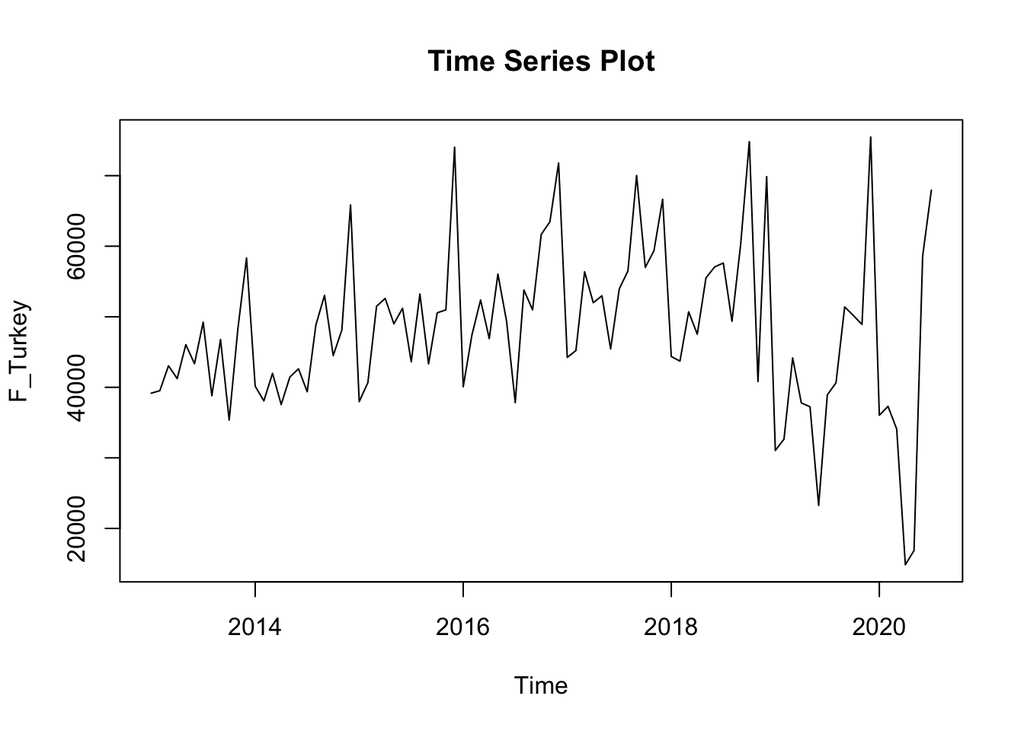

```r
plot(ts_F_Turkey, main = "Time Series Plot", ylab = "F_Turkey")
```

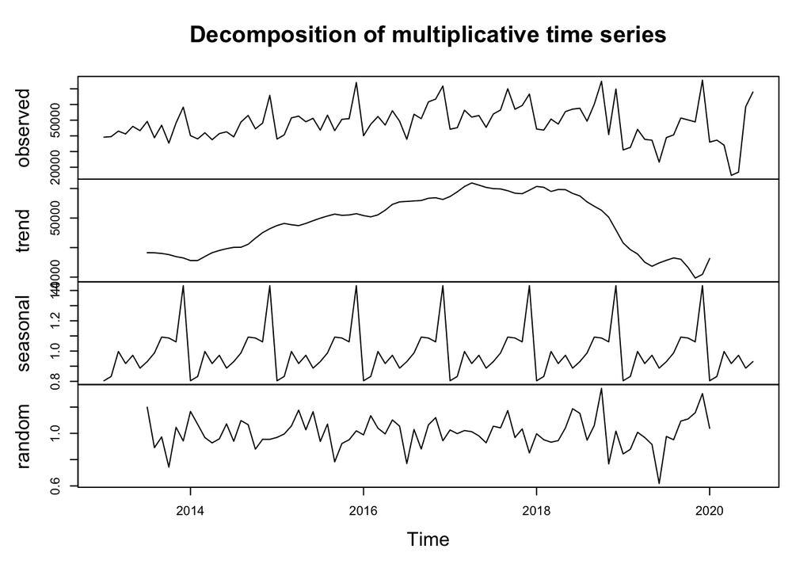

```r
plot(decompose(ts_F_Turkey, type = "multiplicative"))
```

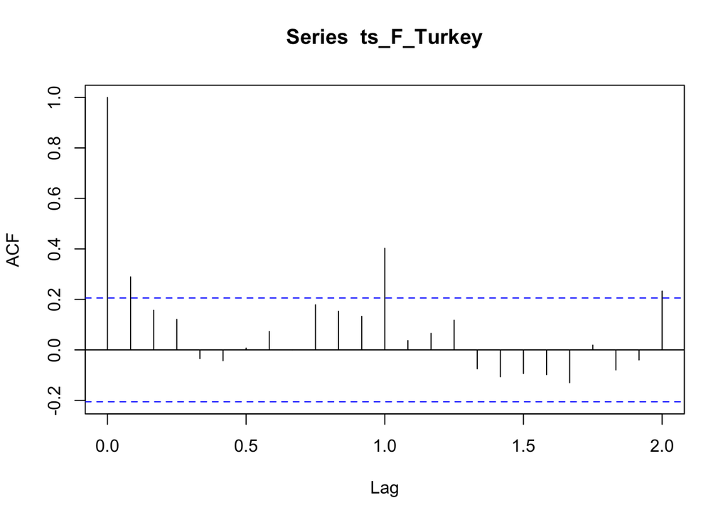

```r
acf(ts_F_Turkey, lag.max = 24)
```

Looking time series plot of the data, it’s seen that variance changes over time. It is decided that transformation is needed due to this non-stationarity. After the logarithmic transformation, you can see the change below.

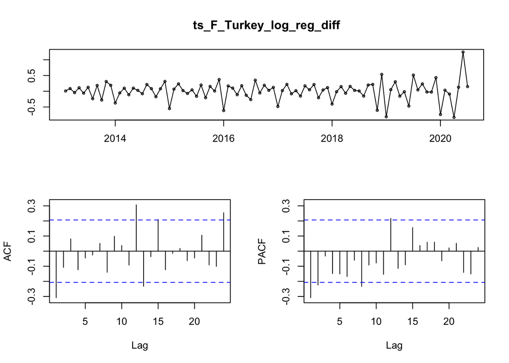

```r
ts_F_Turkey_log <- ts(log(evds$F_Turkey),freq=12,start = 2013)

ts_F_Turkey_log_reg_diff=diff(ts_F_Turkey_log)
tsdisplay(ts_F_Turkey_log_reg_diff, lag.max = 24)
```

After logarithmic transformation, it’s seen that differencing is needed; therefore, one order regular differencing applied. In the figure above, you can see the significant acf values at different lags. They peak at lags 12, 24 and so on. This pattern means seasonality and seasonal differencing is needed.

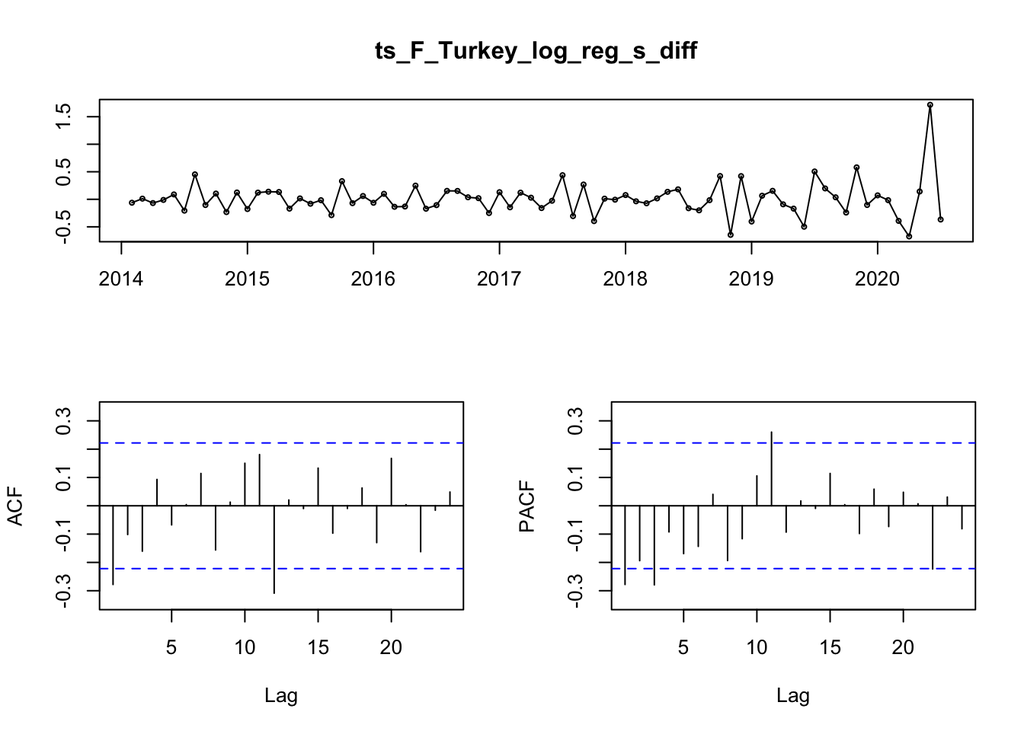

```r
ts_F_Turkey_log_reg_s_diff=diff(ts_F_Turkey_log_reg_diff,12)
tsdisplay(ts_F_Turkey_log_reg_s_diff, lag.max = 24)
```

ACF and PACF plots of the time series suggest ARIMA (1,0,0)(2,0,0) 12.

```r
model_first <- Arima(ts_F_Turkey_log, order=c(1,0,0), seasonal=c(2,0,0))
model_first
```

```
## Series: ts_F_Turkey_log
## ARIMA(1,0,0)(2,0,0)[12] with non-zero mean
##
## Coefficients:
##          ar1    sar1    sar2     mean
##       0.4208  0.3298  0.2609  10.7219
## s.e.  0.0992  0.1266  0.1511   0.0784
##
## sigma^2 estimated as 0.0504:  log likelihood=6.59
## AIC=-3.18   AICc=-2.48   BIC=9.37
```

The statistical evidence can be found with the inspection of the residual of the model. The residuals should be normal and the Q-Q plot can be used to inspection.

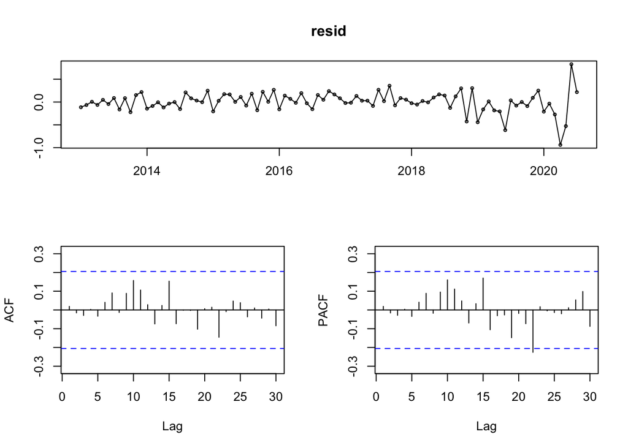

```r
resid <- model_first$residuals
tsdisplay(resid)
```

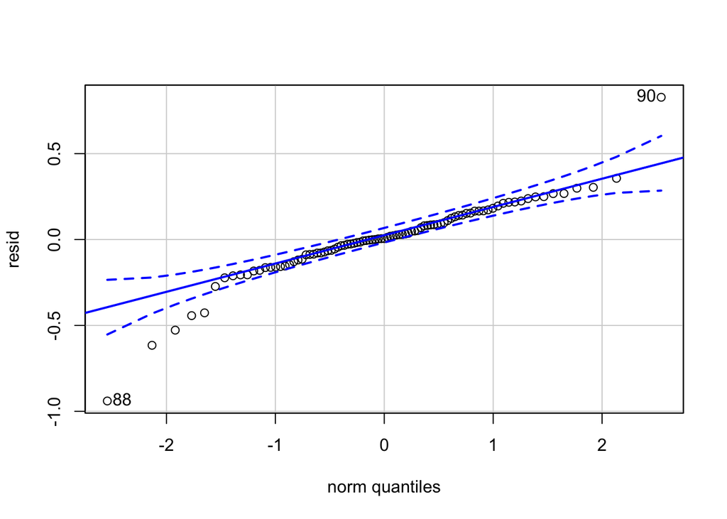

```
## [1] 88 90
```

```r
qqPlot(resid)
```

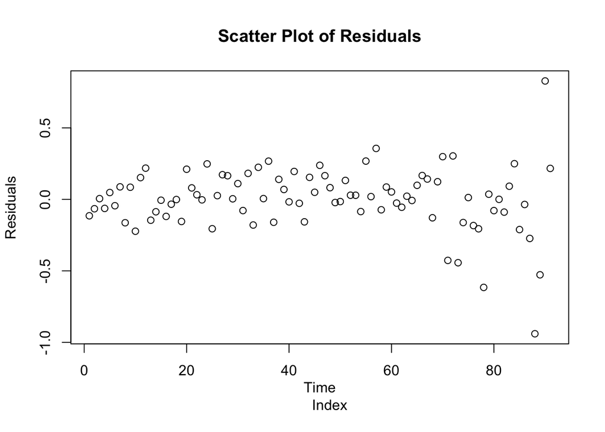

```r
plot(c(model_first$residuals), main="Scatter Plot of Residuals", xlab = "Time
     Index", ylab = "Residuals")
```

## Time Series - Future Prediction (2020-2)

We’re good to go with the model. Therefore, we can now predict next months. Let’s predict the second half of 2020.

```r
forecast_sales=forecast(model_first , h=5)
real_forecast=exp(forecast_sales$mean)
real_forecast
```

```
##           Aug      Sep      Oct      Nov      Dec
## 2020 52731.49 54541.32 55008.15 45789.22 60352.06
```

Note that to make the multiplicative model additive we made log transformation, so we will transform them back to obtained forecast. Plot the forecast to see the pattern.

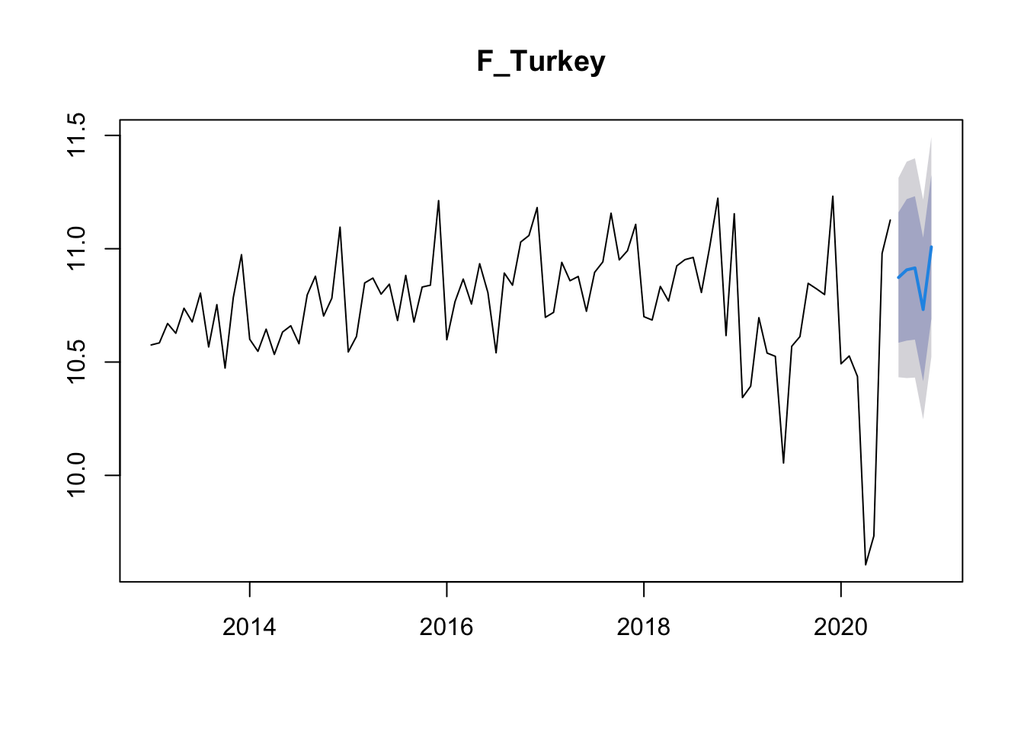

```r
plot(forecast(model_first, h=5), main="F_Turkey")
```

Similar procedures followed and predictions made for second hand sales level(“S_Turkey”) this time.

```
## Series: ts_S_Turkey_log
## ARIMA(2,1,2)(1,0,0)[12]
##
## Coefficients:
##          ar1      ar2      ma1      ma2    sar1
##       0.4310  -0.2886  -0.8297  -0.0815  0.3340
## s.e.  0.3686   0.1972   0.3723   0.3589  0.1389
##
## sigma^2 estimated as 0.04838:  log likelihood=9.71
## AIC=-7.41   AICc=-6.4   BIC=7.59
```

```
##          Point Forecast    Lo 80    Hi 80    Lo 95    Hi 95
## Aug 2020       11.36394 11.08206 11.64581 10.93285 11.79503
## Sep 2020       11.15541 10.82650 11.48433 10.65239 11.65844
## Oct 2020       11.20115 10.87181 11.53048 10.69747 11.70482
## Nov 2020       11.30393 10.97417 11.63369 10.79960 11.80825
## Dec 2020       11.45304 11.12303 11.78306 10.94833 11.95776
```

```r
real_forecast_second
```

```
##           Aug      Sep      Oct      Nov      Dec
## 2020 86157.88 69941.50 73214.24 81139.59 94187.71
```

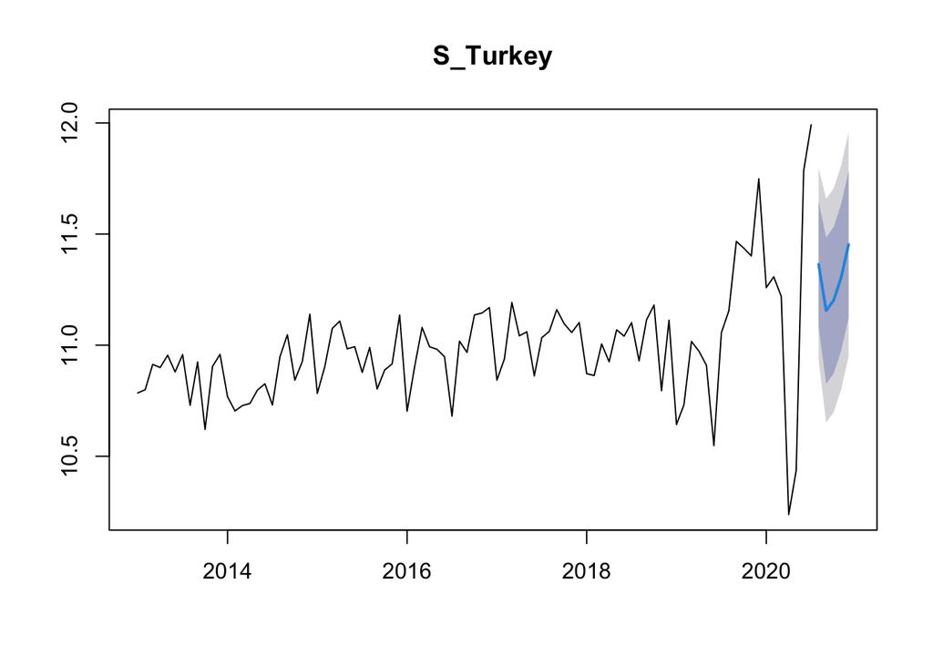

```r
plot(forecast(model_second, h=5), main="S_Turkey")
```

```
## Series: ts_F_Antalya_log
## ARIMA(0,1,1)(2,0,0)[12]
##
## Coefficients:
##           ma1    sar1    sar2
##       -0.8547  0.0973  0.3131
## s.e.   0.0619  0.1331  0.1545
##
## sigma^2 estimated as 0.05123:  log likelihood=5.55
## AIC=-3.09   AICc=-2.62   BIC=6.91
```

```
##          Point Forecast    Lo 80    Hi 80    Lo 95    Hi 95
## Aug 2020       7.204174 6.914115 7.494233 6.760567 7.647780
## Sep 2020       7.268085 6.974981 7.561190 6.819821 7.716350
## Oct 2020       7.346888 7.050769 7.643007 6.894013 7.799763
## Nov 2020       7.216697 6.917594 7.515800 6.759258 7.674136
## Dec 2020       7.373940 7.071883 7.675998 6.911983 7.835898
```

```r
real_forecast_f_antalya
```

```
##           Aug      Sep      Oct      Nov      Dec
## 2020 1345.033 1433.803 1551.361 1361.983 1593.902
```

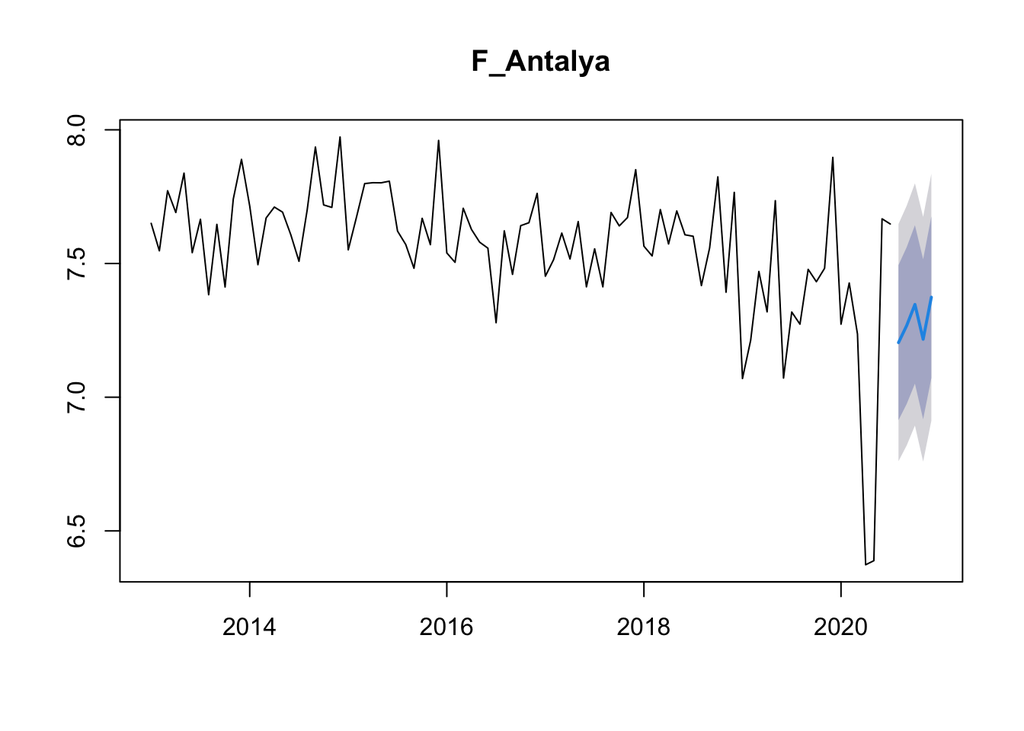

```r
plot(forecast(model_first_antalya, h=5), main="F_Antalya")
```

## Time Series - Future Prediction (2020 Plots)

PS: Note that to make the multiplicative model additive we made log transformation, so we will transform them back to obtained forecasts.

### Turkey First Sale 2020

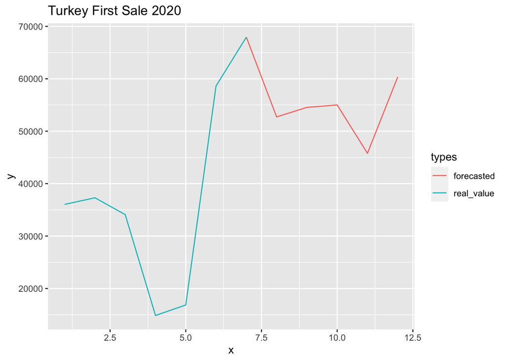

```r
t_first_2020 <- c(ts_F_Turkey[85:91], real_forecast)
plot_list = list(real_value = data.frame(x=c(1:7), y=t_first_2020[1:7]),
                  forecasted = data.frame(x=c(7:12), y=t_first_2020[7:12]))
ggplot(bind_rows(plot_list, .id="types"), aes(x, y, colour=types)) + geom_line() + ggtitle("Turkey First Sale 2020")
```

### Turkey Second Hand Sale 2020

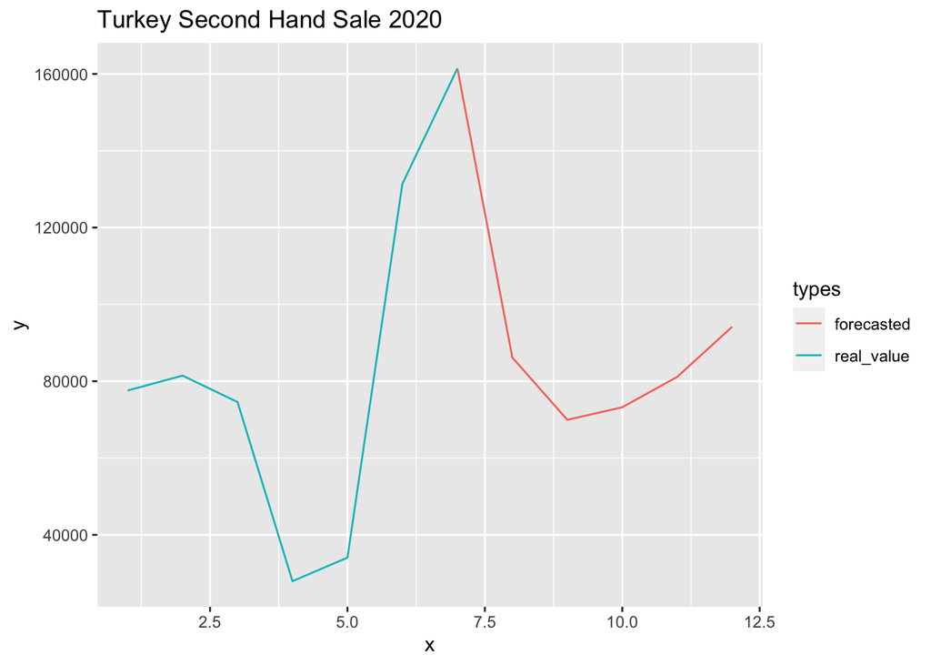

```r
t_second_2020 <- c(ts_S_Turkey[85:91], real_forecast_second)
plot_list = list(real_value = data.frame(x=c(1:7), y=t_second_2020[1:7]),
                  forecasted = data.frame(x=c(7:12), y=t_second_2020[7:12]))
ggplot(bind_rows(plot_list, .id="types"), aes(x, y, colour=types)) + geom_line() + ggtitle("Turkey Second Hand Sale 2020")
```

### Antalya First Sale 2020

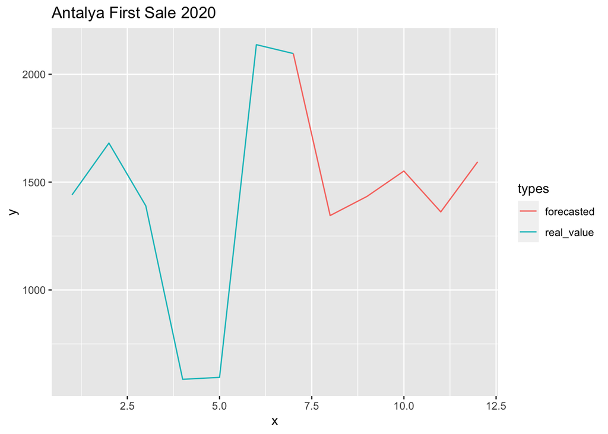

```r
antalya_2020 <- c(ts_F_Antalya[85:91], real_forecast_f_antalya)
plot_list = list(real_value = data.frame(x=c(1:7), y=antalya_2020[1:7]),
                  forecasted = data.frame(x=c(7:12), y=antalya_2020[7:12]))
ggplot(bind_rows(plot_list, .id="types"), aes(x, y, colour=types)) + geom_line() + ggtitle("Antalya First Sale 2020")
```